# COS-D419 Factor Analysis and Structural Equation Models 2023, Assignment 5

Kristiina Räihä

2023-02-21

# CFA invariance & teacher burnout

### Read in the data set:

Start by downloading the **two data files** from Moodle to your Project folder!

```r
MBIelm <- read_csv("data/MBIELM1.CSV", show_col_types = FALSE)
glimpse(MBIelm)
```

```
## Rows: 580
## Columns: 22
## $ ITEM1  <dbl> 1, 5, 3, 6, 1, 5, 3, 6, 2, 4, 5, 2, 3, 2, 5, 6, 5, 4, 6, 3, 1, …
## $ ITEM2  <dbl> 1, 5, 4, 6, 1, 5, 5, 6, 1, 4, 5, 1, 5, 3, 5, 6, 5, 5, 6, 5, 1, …
## $ ITEM3  <dbl> 0, 6, 3, 6, 1, 5, 2, 5, 1, 3, 3, 2, 1, 2, 5, 3, 2, 3, 6, 2, 1, …
## $ ITEM4  <dbl> 6, 6, 6, 6, 6, 6, 6, 6, 5, 6, 5, 6, 3, 6, 6, 6, 5, 6, 6, 6, 6, …
## $ ITEM5  <dbl> 1, 2, 3, 0, 5, 1, 1, 4, 1, 0, 4, 0, 1, 0, 0, 3, 0, 1, 0, 0, 0, …
## $ ITEM6  <dbl> 0, 4, 2, 0, 1, 6, 2, 3, 0, 0, 5, 0, 1, 1, 2, 4, 2, 3, 3, 0, 0, …
## $ ITEM7  <dbl> 6, 5, 6, 6, 6, 6, 6, 5, 6, 5, 6, 6, 5, 6, 6, 6, 5, 6, 6, 6, 6, …
## $ ITEM8  <dbl> 1, 5, 2, 6, 0, 6, 2, 6, 1, 2, 3, 0, 0, 1, 5, 1, 5, 3, 5, 0, 0, …
## $ ITEM9  <dbl> 6, 4, 6, 6, 6, 3, 6, 3, 6, 6, 6, 6, 6, 6, 6, 6, 5, 6, 6, 6, 6, …
## $ ITEM10 <dbl> 0, 3, 2, 0, 0, 0, 2, 4, 0, 1, 3, 0, 1, 0, 0, 0, 3, 0, 0, 3, 0, …
## $ ITEM11 <dbl> 0, 4, 2, 0, 0, 0, 2, 6, 0, 1, 1, 0, 1, 1, 0, 0, 0, 0, 0, 3, 0, …
## $ ITEM12 <dbl> 3, 3, 6, 0, 6, 0, 5, 0, 5, 5, 5, 5, 5, 5, 4, 6, 5, 5, 3, 6, 6, …
## $ ITEM13 <dbl> 1, 3, 2, 0, 2, 5, 2, 5, 1, 1, 4, 0, 2, 1, 5, 2, 5, 1, 5, 0, 0, …
## $ ITEM14 <dbl> 1, 3, 2, 3, 1, 5, 2, 3, 1, 1, 6, 1, 4, 2, 6, 6, 3, 3, 6, 2, 0, …
## $ ITEM15 <dbl> 0, 1, 2, 0, 0, 0, 2, 4, 1, 2, 1, 0, 0, 0, 0, 1, 0, 1, 0, 0, 0, …
## $ ITEM16 <dbl> 0, 4, 2, 0, 1, 6, 2, 3, 0, 1, 3, 0, 1, 0, 2, 2, 1, 3, 3, 0, 0, …
## $ ITEM17 <dbl> 6, 4, 2, 6, 6, 5, 6, 4, 6, 6, 5, 6, 5, 5, 6, 6, 5, 6, 6, 6, 6, …
## $ ITEM18 <dbl> 3, 5, 5, 4, 5, 1, 5, 1, 6, 6, 4, 5, 5, 4, 6, 6, 3, 5, 5, 6, 6, …
## $ ITEM19 <dbl> 5, 5, 6, 6, 4, 3, 5, 1, 6, 6, 5, 6, 5, 3, 5, 6, 4, 5, 6, 5, 6, …
## $ ITEM20 <dbl> 0, 1, 1, 3, 1, 1, 1, 5, 1, 0, 1, 0, 1, 0, 1, 4, 4, 2, 3, 0, 0, …
## $ ITEM21 <dbl> 5, 3, 3, 6, 5, 5, 5, 3, 1, 5, 6, 5, 1, 5, 6, 5, 4, 5, 6, 6, 6, …
## $ ITEM22 <dbl> 0, 2, 2, 0, 1, 0, 5, 1, 0, 1, 4, 1, 1, 1, 0, 0, 0, 5, 1, 0, 0, …
```

```r
MBIsec <- read_csv("data/MBISEC1.CSV", show_col_types = FALSE)
glimpse(MBIsec)
```

```
## Rows: 692
## Columns: 22
## $ ITEM1  <dbl> 3, 3, 5, 5, 1, 2, 5, 5, 1, 3, 5, 0, 1, 4, 4, 4, 5, 1, 2, 3, 2, …
## $ ITEM2  <dbl> 4, 5, 5, 5, 2, 4, 5, 5, 3, 5, 5, 0, 3, 4, 5, 4, 5, 2, 2, 4, 3, …
## $ ITEM3  <dbl> 0, 3, 5, 3, 1, 0, 2, 1, 3, 5, 4, 0, 1, 5, 3, 2, 3, 0, 2, 4, 0, …
## $ ITEM4  <dbl> 6, 5, 5, 4, 6, 6, 5, 6, 3, 5, 6, 6, 6, 6, 4, 6, 6, 3, 6, 6, 4, …
## $ ITEM5  <dbl> 0, 1, 0, 1, 1, 1, 0, 1, 1, 1, 2, 1, 0, 1, 5, 0, 0, 0, 1, 1, 0, …
## $ ITEM6  <dbl> 2, 1, 5, 3, 3, 2, 3, 2, 1, 2, 4, 0, 0, 2, 5, 3, 1, 1, 0, 1, 1, …
## $ ITEM7  <dbl> 6, 3, 5, 5, 5, 5, 5, 6, 5, 5, 5, 5, 6, 6, 3, 5, 4, 3, 4, 6, 6, …
## $ ITEM8  <dbl> 1, 2, 5, 2, 1, 2, 2, 1, 1, 3, 1, 0, 1, 3, 3, 3, 3, 2, 0, 1, 1, …
## $ ITEM9  <dbl> 5, 3, 4, 5, 5, 5, 5, 6, 6, 3, 6, 6, 6, 5, 1, 3, 4, 4, 5, 5, 6, …
## $ ITEM10 <dbl> 1, 2, 1, 1, 0, 4, 2, 1, 1, 0, 0, 0, 0, 2, 2, 2, 0, 1, 1, 0, 0, …
## $ ITEM11 <dbl> 2, 2, 2, 1, 0, 2, 1, 0, 1, 0, 0, 0, 0, 3, 1, 2, 0, 0, 0, 0, 1, …
## $ ITEM12 <dbl> 5, 5, 5, 4, 2, 5, 5, 5, 5, 2, 4, 6, 6, 6, 4, 4, 4, 3, 4, 5, 6, …
## $ ITEM13 <dbl> 1, 3, 5, 2, 1, 2, 4, 2, 1, 2, 6, 0, 0, 5, 5, 4, 3, 3, 2, 1, 1, …
## $ ITEM14 <dbl> 3, 3, 4, 4, 1, 0, 3, 4, 1, 5, 4, 0, 1, 3, 4, 2, 4, 4, 1, 2, 1, …
## $ ITEM15 <dbl> 0, 2, 0, 0, 1, 1, 1, 0, 0, 1, 1, 0, 0, 1, 2, 0, 0, 2, 1, 0, 0, …
## $ ITEM16 <dbl> 3, 2, 1, 1, 3, 1, 3, 1, 1, 3, 4, 0, 0, 1, 3, 3, 3, 1, 1, 1, 1, …
## $ ITEM17 <dbl> 6, 5, 5, 5, 4, 5, 5, 6, 6, 6, 5, 6, 6, 6, 4, 6, 6, 5, 5, 5, 6, …
## $ ITEM18 <dbl> 5, 5, 4, 4, 4, 5, 5, 5, 5, 4, 6, 6, 6, 6, 5, 4, 6, 4, 5, 5, 6, …
## $ ITEM19 <dbl> 5, 5, 4, 5, 5, 4, 3, 5, 6, 4, 5, 6, 6, 6, 3, 3, 4, 5, 4, 5, 6, …
## $ ITEM20 <dbl> 1, 0, 4, 1, 1, 1, 1, 1, 1, 1, 1, 0, 0, 1, 2, 0, 2, 0, 1, 1, 0, …
## $ ITEM21 <dbl> 5, 5, 4, 3, 4, 3, 5, 6, 3, 3, 5, 3, 6, 6, 4, 6, 0, 1, 5, 6, 6, …
## $ ITEM22 <dbl> 1, 1, 0, 1, 5, 2, 1, 1, 2, 2, 2, 1, 2, 1, 4, 0, 0, 0, 1, 0, 1, …
```

### Explore the data (always do that!):

```r
library(tidyverse)
library(hrbrthemes)
library(viridis)
```

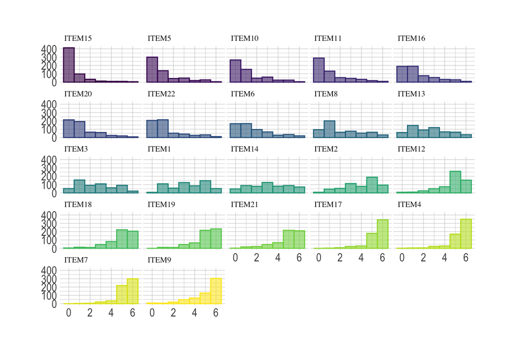

```r
library(forcats)
library(ggplot2)
library(extrafont)
loadfonts(device = "win")
# plot
data1 <- MBIelm
data1 <- data1 %>%
  gather(key="text", value="value") %>%
  mutate(text = gsub("\\.", " ",text)) %>%
  mutate(value = round(as.numeric(value),0))

p1 <- data1 %>%
  mutate(text = fct_reorder(text, value)) %>%
  ggplot(aes(x=value, color=text, fill=text)) +
    geom_histogram(alpha=0.6, binwidth = 1) +
    scale_fill_viridis(discrete=TRUE) +
    scale_color_viridis(discrete=TRUE) +
    theme_ipsum() +
    theme(
      legend.position="none",
      panel.spacing = unit(0.1, "lines"),
      strip.text.x = element_text(size = 8, family="serif"),
    ) +
    xlab("") +
    ylab("") +
    facet_wrap(~text)

p1
```

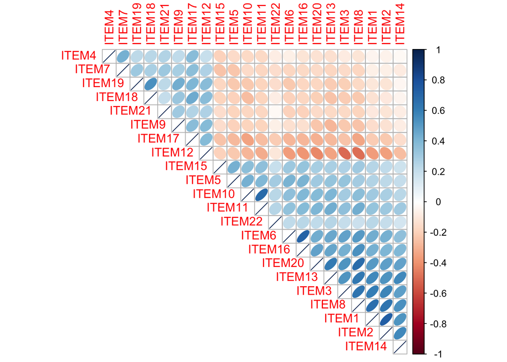

```r
MBIelm %>%
  cor() %>% corrplot(method = 'ellipse', order = 'AOE', type = 'upper')
```

```r
d1 <- psych::describe(MBIsec)
d1
```

|  | vars | n | mean | sd | median | trimmed | mad | min | max | range | skew | kurtosis | se |
| --- | --- | --- | --- | --- | --- | --- | --- | --- | --- | --- | --- | --- | --- |
| ITEM1 | 1 | 692 | 3.371387 | 1.5866454 | 3 | 3.4169675 | 2.2239 | 0 | 6 | 6 | -0.23465279 | -1.03497481 | 0.06031521 |
| ITEM2 | 2 | 692 | 3.890173 | 1.5290970 | 4 | 4.0000000 | 1.4826 | 0 | 6 | 6 | -0.58638631 | -0.61315398 | 0.05812755 |
| ITEM3 | 3 | 692 | 2.526012 | 1.7006561 | 2 | 2.4693141 | 1.4826 | 0 | 6 | 6 | 0.36181823 | -0.97947030 | 0.06464925 |
| ITEM4 | 4 | 692 | 5.167630 | 1.1029200 | 5 | 5.3953069 | 1.4826 | 0 | 6 | 6 | -1.85906328 | 4.05793754 | 0.04192673 |
| ITEM5 | 5 | 692 | 1.216763 | 1.4681794 | 1 | 0.9657040 | 1.4826 | 0 | 6 | 6 | 1.19559813 | 0.64453721 | 0.05581181 |
| ITEM6 | 6 | 692 | 1.998555 | 1.6507677 | 2 | 1.8447653 | 1.4826 | 0 | 6 | 6 | 0.65764040 | -0.55290151 | 0.06275277 |
| ITEM7 | 7 | 692 | 5.014451 | 1.1373513 | 5 | 5.1985560 | 1.4826 | 0 | 6 | 6 | -1.30709598 | 1.41285299 | 0.04323561 |
| ITEM8 | 8 | 692 | 2.143064 | 1.7075794 | 2 | 2.0000000 | 1.4826 | 0 | 6 | 6 | 0.69489000 | -0.57025994 | 0.06491243 |
| ITEM9 | 9 | 692 | 4.702312 | 1.4941644 | 5 | 4.9638989 | 1.4826 | 0 | 6 | 6 | -1.23119953 | 0.73962359 | 0.05679961 |
| ITEM10 | 10 | 692 | 1.274566 | 1.5656554 | 1 | 0.9819495 | 1.4826 | 0 | 6 | 6 | 1.35043059 | 1.05213318 | 0.05951729 |

[output cut: 12 more lines]

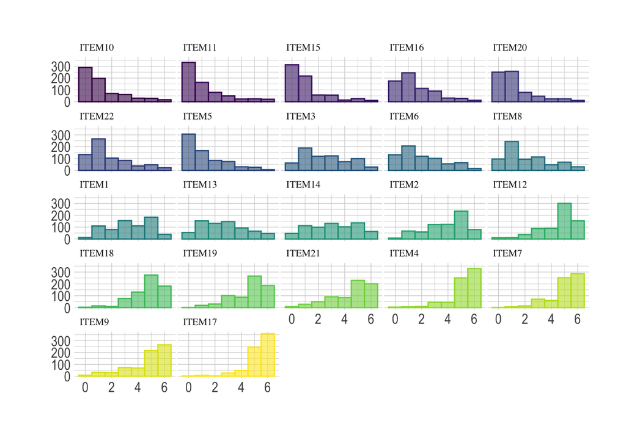

```r
# plot
data2 <- MBIsec
data2 <- data2 %>%
  gather(key="text", value="value") %>%
  mutate(text = gsub("\\.", " ",text)) %>%
  mutate(value = round(as.numeric(value),0))

p2 <- data2 %>%
  mutate(text = fct_reorder(text, value)) %>%
  ggplot(aes(x=value, color=text, fill=text)) +
    geom_histogram(alpha=0.6, binwidth = 1) +
    scale_fill_viridis(discrete=TRUE) +
    scale_color_viridis(discrete=TRUE) +
    theme_ipsum() +
    theme(
      legend.position="none",
      panel.spacing = unit(0.1, "lines"),
      strip.text.x = element_text(size = 8, family="serif"),
    ) +
    xlab("") +
    ylab("") +
    facet_wrap(~text)

p2
```

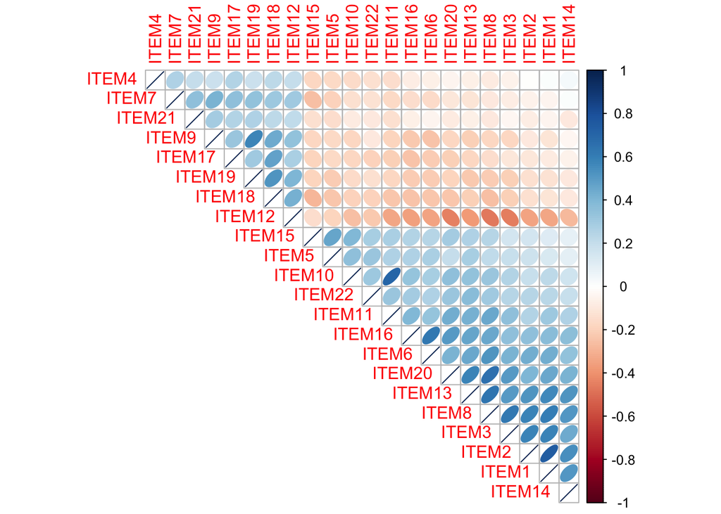

```r
MBIsec %>%
  cor() %>% corrplot(method = 'ellipse', order = 'AOE', type = 'upper')
```

## Exercise 5.1

### Define and estimate the initial baseline models

Assignment: “Begin by estimating the model **separately for both groups**. Then follow the instructions Exercise 5.1 until you have the final baseline models for each group.”

```r
library(lavaan)

# Define a CFA model using the lavaan (Latent Variable Analysis) syntax:
# see https://lavaan.ugent.be/tutorial/syntax1.html

BLmodel <- '
# CFA model for the burnout:
# EE: EmotionalExhaustion
# DP: Depersonalization
# PA: PersonalAccomplishment
  EE =~ ITEM1 + ITEM2 + ITEM3 + ITEM6 + ITEM8 + ITEM13 + ITEM14 + ITEM16 + ITEM20
  DP =~ ITEM5 + ITEM10 + ITEM11 + ITEM15 + ITEM22
  PA =~ ITEM4 + ITEM7 + ITEM9 + ITEM12 + ITEM17 + ITEM18 + ITEM19 + ITEM21
'

# MBIelm data

# Use a robust (MLM) estimator:
cfa_bl <- cfa(BLmodel, data = MBIelm, estimator = "MLM")

# Numerical summary of the model:
summary(cfa_bl, fit.measures = TRUE, standardized = TRUE)
```

```
## lavaan 0.6.13 ended normally after 51 iterations
##
##   Estimator                                         ML
##   Optimization method                           NLMINB
##   Number of model parameters                        47
##
##   Number of observations                           580
##
## Model Test User Model:
##                                               Standard      Scaled
##   Test Statistic                              1012.654     802.743
##   Degrees of freedom                               206         206
##   P-value (Chi-square)                           0.000       0.000
##   Scaling correction factor                                  1.261
##     Satorra-Bentler correction
##
## Model Test Baseline Model:
##
##   Test statistic                              5608.130    4354.842
##   Degrees of freedom                               231         231
##   P-value                                        0.000       0.000
##   Scaling correction factor                                  1.288
##
## User Model versus Baseline Model:
##
##   Comparative Fit Index (CFI)                    0.850       0.855
##   Tucker-Lewis Index (TLI)                       0.832       0.838
##
##   Robust Comparative Fit Index (CFI)                         0.858
##   Robust Tucker-Lewis Index (TLI)                            0.841
##
## Loglikelihood and Information Criteria:
##
##   Loglikelihood user model (H0)             -19894.031  -19894.031
##   Loglikelihood unrestricted model (H1)     -19387.704  -19387.704
##
##   Akaike (AIC)                               39882.062   39882.062
##   Bayesian (BIC)                             40087.125   40087.125
##   Sample-size adjusted Bayesian (SABIC)      39937.918   39937.918
##
```

[output cut: 72 more lines]

```
##    .ITEM10            0.806    0.100    8.061    0.000    0.806    0.370
##    .ITEM11            0.848    0.113    7.539    0.000    0.848    0.372
##    .ITEM15            0.934    0.128    7.323    0.000    0.934    0.745
##    .ITEM22            2.086    0.159   13.152    0.000    2.086    0.877
##    .ITEM4             0.696    0.085    8.233    0.000    0.696    0.800
##    .ITEM7             0.562    0.073    7.714    0.000    0.562    0.734
##    .ITEM9             1.176    0.131    9.007    0.000    1.176    0.662
##    .ITEM12            1.039    0.109    9.546    0.000    1.039    0.627
##    .ITEM17            0.418    0.055    7.643    0.000    0.418    0.536
##    .ITEM18            0.894    0.120    7.447    0.000    0.894    0.606
##    .ITEM19            0.753    0.075   10.101    0.000    0.753    0.587
##    .ITEM21            1.360    0.130   10.435    0.000    1.360    0.819
##     EE                1.657    0.112   14.736    0.000    1.000    1.000
##     DP                0.723    0.129    5.608    0.000    1.000    1.000
##     PA                0.174    0.047    3.686    0.000    1.000    1.000
```

```r
# Summary of model
fit_bl <- fitMeasures(cfa_bl, c("chisq.scaled", "df.scaled", "pvalue.scaled",
          "cfi.robust", "tli.robust", "rmsea.robust", "rmsea.ci.lower.robust",
          "rmsea.ci.upper.robust", "srmr"), output = "matrix")

fit.bl <- as.data.frame(t(fit_bl))
fit.bl
```

|  | chisq.scaled | df.scaled | pvalue.scaled | cfi.robust | tli.robust | rmsea.robust | rmsea.ci.lower.robust | rmsea.ci.upper.robust | srmr |
| --- | --- | --- | --- | --- | --- | --- | --- | --- | --- |
|  | 802.7431 | 206 | 0 | 0.8582496 | 0.8410469 | 0.07937584 | 0.07363041 | 0.08520338 | 0.07068205 |

```r
# Generate MI Table
MI_MBIelm <- modindices(cfa_bl, standardized = TRUE, sort. = TRUE, maximum.number = 10)
#View(MI_MBIelm)

# MBIsec data

# Use a robust (MLM) estimator:
cfa_bl2 <- cfa(BLmodel, data = MBIsec, estimator = "MLM")

# Numerical summary of the model:
summary(cfa_bl2, fit.measures = TRUE, standardized = TRUE)
```

```
## lavaan 0.6.13 ended normally after 52 iterations
##
##   Estimator                                         ML
##   Optimization method                           NLMINB
##   Number of model parameters                        47
##
##   Number of observations                           692
##
## Model Test User Model:
##                                               Standard      Scaled
##   Test Statistic                              1283.053     971.064
##   Degrees of freedom                               206         206
##   P-value (Chi-square)                           0.000       0.000
##   Scaling correction factor                                  1.321
##     Satorra-Bentler correction
##
## Model Test Baseline Model:
##
##   Test statistic                              6432.706    4901.792
##   Degrees of freedom                               231         231
##   P-value                                        0.000       0.000
##   Scaling correction factor                                  1.312
##
## User Model versus Baseline Model:
##
##   Comparative Fit Index (CFI)                    0.826       0.836
##   Tucker-Lewis Index (TLI)                       0.805       0.816
##
##   Robust Comparative Fit Index (CFI)                         0.835
##   Robust Tucker-Lewis Index (TLI)                            0.815
##
## Loglikelihood and Information Criteria:
##
##   Loglikelihood user model (H0)             -24601.135  -24601.135
##   Loglikelihood unrestricted model (H1)     -23959.608  -23959.608
##
##   Akaike (AIC)                               49296.269   49296.269
##   Bayesian (BIC)                             49509.630   49509.630
##   Sample-size adjusted Bayesian (SABIC)      49360.397   49360.397
##
```

[output cut: 72 more lines]

```
##    .ITEM10            0.803    0.093    8.668    0.000    0.803    0.328
##    .ITEM11            0.854    0.114    7.517    0.000    0.854    0.347
##    .ITEM15            1.562    0.134   11.628    0.000    1.562    0.778
##    .ITEM22            2.052    0.128   16.020    0.000    2.052    0.800
##    .ITEM4             1.074    0.111    9.652    0.000    1.074    0.884
##    .ITEM7             0.907    0.070   12.961    0.000    0.907    0.703
##    .ITEM9             1.194    0.114   10.436    0.000    1.194    0.536
##    .ITEM12            1.177    0.109   10.779    0.000    1.177    0.657
##    .ITEM17            0.649    0.076    8.553    0.000    0.649    0.701
##    .ITEM18            0.703    0.074    9.453    0.000    0.703    0.512
##    .ITEM19            0.847    0.080   10.618    0.000    0.847    0.501
##    .ITEM21            1.889    0.120   15.762    0.000    1.889    0.832
##     EE                1.436    0.103   13.950    0.000    1.000    1.000
##     DP                0.442    0.098    4.508    0.000    1.000    1.000
##     PA                0.141    0.036    3.936    0.000    1.000    1.000
```

```r
# Summary of model
fit_bl2 <- fitMeasures(cfa_bl2, c("chisq.scaled", "df.scaled", "pvalue.scaled",
          "cfi.robust", "tli.robust", "rmsea.robust", "rmsea.ci.lower.robust",
          "rmsea.ci.upper.robust", "srmr"), output = "matrix")

fit.bl2 <- as.data.frame(t(fit_bl2))
fit.bl2
```

|  | chisq.scaled | df.scaled | pvalue.scaled | cfi.robust | tli.robust | rmsea.robust | rmsea.ci.lower.robust | rmsea.ci.upper.robust | srmr |
| --- | --- | --- | --- | --- | --- | --- | --- | --- | --- |
|  | 971.0638 | 206 | 0 | 0.8350831 | 0.8150689 | 0.08420941 | 0.07891501 | 0.08958128 | 0.07978851 |

```r
# Generate MI Table
MI_MBIsec <- modindices(cfa_bl2, standardized = TRUE, sort. = TRUE, maximum.number = 10)

#View(MI_MBIsec)

# Combined fit table
tablex <- rbind(fit.bl, fit.bl2)

#View(tablex)
```

Modiﬁcation indices quite similar with both samples: one cross-loading and three residual covariances (output omitted).

## Estimating model 2

Based on this pattern and the knowledge for male elementary teachers (ch4), we (exceptionally) include all four parameters in the post-hoc models at once (not one at a time as usual).

```r
first4mods <- '
# first four modifications (common to the groups):
EE =~ ITEM12
ITEM6 ~~ ITEM16
ITEM10 ~~ ITEM11
ITEM1 ~~ ITEM2
'
BLmodelelm <- paste(BLmodel, first4mods, sep = "\n  ")

# and as they are (still) equal to both groups, we may just copy the whole model:

BLmodelsec <- BLmodelelm


# Elementary Teachers

CFA_Ele2 <- cfa(BLmodelsec, data = MBIelm, estimator = "MLM")


summary(CFA_Ele2, fit.measures = TRUE, standardized = TRUE)
```

```
## lavaan 0.6.13 ended normally after 53 iterations
##
##   Estimator                                         ML
##   Optimization method                           NLMINB
##   Number of model parameters                        51
##
##   Number of observations                           580
##
## Model Test User Model:
##                                               Standard      Scaled
##   Test Statistic                               584.871     470.377
##   Degrees of freedom                               202         202
##   P-value (Chi-square)                           0.000       0.000
##   Scaling correction factor                                  1.243
##     Satorra-Bentler correction
##
## Model Test Baseline Model:
##
##   Test statistic                              5608.130    4354.842
##   Degrees of freedom                               231         231
##   P-value                                        0.000       0.000
##   Scaling correction factor                                  1.288
##
## User Model versus Baseline Model:
##
##   Comparative Fit Index (CFI)                    0.929       0.935
##   Tucker-Lewis Index (TLI)                       0.919       0.926
##
##   Robust Comparative Fit Index (CFI)                         0.937
##   Robust Tucker-Lewis Index (TLI)                            0.928
##
## Loglikelihood and Information Criteria:
##
##   Loglikelihood user model (H0)             -19680.140  -19680.140
##   Loglikelihood unrestricted model (H1)     -19387.704  -19387.704
##
##   Akaike (AIC)                               39462.279   39462.279
##   Bayesian (BIC)                             39684.794   39684.794
##   Sample-size adjusted Bayesian (SABIC)      39522.888   39522.888
##
```

[output cut: 80 more lines]

```
##    .ITEM10            1.235    0.123   10.068    0.000    1.235    0.567
##    .ITEM11            1.300    0.128   10.174    0.000    1.300    0.570
##    .ITEM15            0.848    0.125    6.813    0.000    0.848    0.676
##    .ITEM22            2.014    0.156   12.884    0.000    2.014    0.846
##    .ITEM4             0.684    0.083    8.250    0.000    0.684    0.786
##    .ITEM7             0.550    0.071    7.724    0.000    0.550    0.718
##    .ITEM9             1.175    0.132    8.923    0.000    1.175    0.662
##    .ITEM12            0.944    0.094    9.999    0.000    0.944    0.570
##    .ITEM17            0.419    0.054    7.687    0.000    0.419    0.536
##    .ITEM18            0.878    0.119    7.367    0.000    0.878    0.595
##    .ITEM19            0.726    0.073   10.008    0.000    0.726    0.566
##    .ITEM21            1.361    0.130   10.458    0.000    1.361    0.819
##     EE                1.542    0.113   13.639    0.000    1.000    1.000
##     DP                0.926    0.142    6.533    0.000    1.000    1.000
##     PA                0.186    0.050    3.736    0.000    1.000    1.000
```

```r
fit_ele2 <- fitMeasures(CFA_Ele2, c("chisq.scaled", "df.scaled", "pvalue.scaled",
              "cfi.robust", "tli.robust", "rmsea.robust", "rmsea.ci.lower.robust",
              "rmsea.ci.upper.robust", "srmr", "chisq.scaling.factor"),
              output = "matrix")

MI_Ele2 <- modindices(CFA_Ele2, standardized = TRUE, sort. = TRUE, maximum.number = 10)
MI_Ele2
```

|  | lhs | op | rhs | mi | epc | sepc.lv | sepc.all | sepc.nox |
| --- | --- | --- | --- | --- | --- | --- | --- | --- |
| 298 | ITEM4 | ~~ | ITEM7 | 38.93096 | 0.1740657 | 0.1740657 | 0.2839860 | 0.2839860 |
| 323 | ITEM18 | ~~ | ITEM19 | 38.74400 | 0.2661335 | 0.2661335 | 0.3334005 | 0.3334005 |
| 90 | PA | =~ | ITEM14 | 24.43540 | 0.8644826 | 0.3730836 | 0.2047184 | 0.2047184 |
| 152 | ITEM3 | ~~ | ITEM12 | 23.97798 | -0.2501305 | -0.2501305 | -0.2271606 | -0.2271606 |
| 202 | ITEM13 | ~~ | ITEM12 | 20.49301 | 0.2309706 | 0.2309706 | 0.2106914 | 0.2106914 |
| 122 | ITEM2 | ~~ | ITEM14 | 16.44108 | 0.2447245 | 0.2447245 | 0.1628085 | 0.1628085 |
| 74 | DP | =~ | ITEM16 | 15.73272 | 0.3102036 | 0.2985625 | 0.1965440 | 0.1965440 |
| 191 | ITEM13 | ~~ | ITEM14 | 14.83842 | 0.2814701 | 0.2814701 | 0.1802753 | 0.1802753 |
| 57 | EE | =~ | ITEM11 | 14.74968 | 0.2500868 | 0.3105306 | 0.2055058 | 0.2055058 |
| 80 | DP | =~ | ITEM17 | 12.78758 | -0.1725638 | -0.1660879 | -0.1879618 | -0.1879618 |

```r
#Secondary Teachers

CFA_Sec2 <- cfa(BLmodelsec, data = MBIsec, estimator = "MLM")
CFA_Sec2
```

```
## lavaan 0.6.13 ended normally after 51 iterations
##
##   Estimator                                         ML
##   Optimization method                           NLMINB
##   Number of model parameters                        51
##
##   Number of observations                           692
##
## Model Test User Model:
##                                               Standard      Scaled
##   Test Statistic                               750.857     572.552
##   Degrees of freedom                               202         202
##   P-value (Chi-square)                           0.000       0.000
##   Scaling correction factor                                  1.311
##     Satorra-Bentler correction
```

```r
summary(CFA_Sec2, fit.measures = TRUE, standardized = TRUE)
```

```
## lavaan 0.6.13 ended normally after 51 iterations
##
##   Estimator                                         ML
##   Optimization method                           NLMINB
##   Number of model parameters                        51
##
##   Number of observations                           692
##
## Model Test User Model:
##                                               Standard      Scaled
##   Test Statistic                               750.857     572.552
##   Degrees of freedom                               202         202
##   P-value (Chi-square)                           0.000       0.000
##   Scaling correction factor                                  1.311
##     Satorra-Bentler correction
##
## Model Test Baseline Model:
##
##   Test statistic                              6432.706    4901.792
##   Degrees of freedom                               231         231
##   P-value                                        0.000       0.000
##   Scaling correction factor                                  1.312
##
## User Model versus Baseline Model:
##
##   Comparative Fit Index (CFI)                    0.911       0.921
##   Tucker-Lewis Index (TLI)                       0.899       0.909
##
##   Robust Comparative Fit Index (CFI)                         0.921
##   Robust Tucker-Lewis Index (TLI)                            0.909
##
## Loglikelihood and Information Criteria:
##
##   Loglikelihood user model (H0)             -24335.037  -24335.037
##   Loglikelihood unrestricted model (H1)     -23959.608  -23959.608
##
##   Akaike (AIC)                               48772.074   48772.074
##   Bayesian (BIC)                             49003.593   49003.593
##   Sample-size adjusted Bayesian (SABIC)      48841.659   48841.659
##
```

[output cut: 80 more lines]

```
##    .ITEM10            1.520    0.129   11.773    0.000    1.520    0.621
##    .ITEM11            1.618    0.142   11.377    0.000    1.618    0.657
##    .ITEM15            1.288    0.133    9.693    0.000    1.288    0.641
##    .ITEM22            1.818    0.131   13.833    0.000    1.818    0.709
##    .ITEM4             1.067    0.110    9.662    0.000    1.067    0.879
##    .ITEM7             0.888    0.070   12.778    0.000    0.888    0.688
##    .ITEM9             1.175    0.115   10.236    0.000    1.175    0.527
##    .ITEM12            1.006    0.081   12.456    0.000    1.006    0.561
##    .ITEM17            0.645    0.075    8.603    0.000    0.645    0.697
##    .ITEM18            0.699    0.074    9.493    0.000    0.699    0.510
##    .ITEM19            0.838    0.081   10.286    0.000    0.838    0.496
##    .ITEM21            1.874    0.121   15.509    0.000    1.874    0.825
##     EE                1.272    0.103   12.407    0.000    1.000    1.000
##     DP                0.751    0.128    5.883    0.000    1.000    1.000
##     PA                0.147    0.036    4.049    0.000    1.000    1.000
```

```r
fit_sec2 <- fitMeasures(CFA_Sec2, c("chisq.scaled", "df.scaled", "pvalue.scaled",
              "cfi.robust", "tli.robust", "rmsea.robust", "rmsea.ci.lower.robust",
              "rmsea.ci.upper.robust", "srmr", "chisq.scaling.factor"), output = "matrix")

MI_Sec2 <- modindices(CFA_Sec2, standardized = TRUE, sort. = TRUE, maximum.number = 10)
MI_Sec2
```

|  | lhs | op | rhs | mi | epc | sepc.lv | sepc.all | sepc.nox |
| --- | --- | --- | --- | --- | --- | --- | --- | --- |
| 57 | EE | =~ | ITEM11 | 67.17686 | 0.4717302 | 0.5321242 | 0.3391140 | 0.3391140 |
| 314 | ITEM9 | ~~ | ITEM19 | 43.69015 | 0.3545875 | 0.3545875 | 0.3573421 | 0.3573421 |
| 251 | ITEM5 | ~~ | ITEM15 | 35.57582 | 0.4162330 | 0.4162330 | 0.3098260 | 0.3098260 |
| 271 | ITEM11 | ~~ | ITEM15 | 29.01639 | -0.2971416 | -0.2971416 | -0.2058625 | -0.2058625 |
| 222 | ITEM16 | ~~ | ITEM20 | 28.89975 | 0.2266115 | 0.2266115 | 0.2009362 | 0.2009362 |
| 73 | DP | =~ | ITEM14 | 22.14496 | -0.4897152 | -0.4243932 | -0.2392742 | -0.2392742 |
| 320 | ITEM17 | ~~ | ITEM18 | 21.58316 | 0.1469299 | 0.1469299 | 0.2187855 | 0.2187855 |
| 310 | ITEM7 | ~~ | ITEM21 | 21.37017 | 0.2466251 | 0.2466251 | 0.1911282 | 0.1911282 |
| 321 | ITEM17 | ~~ | ITEM19 | 20.74234 | -0.1594002 | -0.1594002 | -0.2168249 | -0.2168249 |
| 124 | ITEM2 | ~~ | ITEM20 | 20.02011 | -0.1709041 | -0.1709041 | -0.1620551 | -0.1620551 |

“Then continue fitting and modifying both two models separately, one step at a time (from now on, the two models can be different from each other: the principle of *Partial Measurement Invariance* lets them to differ while still making it possible to continue with multigroup analyses.”

**Just follow Byrne’s ideas here. Do not implement any additional modifications.**

# Estimating model 3

MODEL MODIFICATION INDICES (Elementary teachers)

ITEM7 “WITH” ITEM4 (~~ is correlated with) ITEM19 “WITH” ITEM18

“According to Byrne, there is a clear overlap of content between Item7 and Item4 but not between Item19 and Item18”, thus only the first modification is applied.

```r
Model3_Ele <- '# Added ITEM7 "WITH" ITEM4
EE =~ ITEM1 + ITEM2 + ITEM3 + ITEM6 + ITEM8 + ITEM13 + ITEM14 + ITEM16 + ITEM20
DP =~ ITEM5 + ITEM10 + ITEM11 + ITEM15 + ITEM22
PA =~ ITEM4 + ITEM7 + ITEM9 + ITEM12 + ITEM17 + ITEM18 + ITEM19 + ITEM21
EE =~ ITEM12
ITEM6 ~~ ITEM16
ITEM10 ~~ ITEM11
ITEM1 ~~ ITEM2
ITEM4 ~~ ITEM7
'

CFA_Ele3 <- cfa(Model3_Ele, data = MBIelm, estimator = "MLM")
CFA_Ele3
```

```
## lavaan 0.6.13 ended normally after 55 iterations
##
##   Estimator                                         ML
##   Optimization method                           NLMINB
##   Number of model parameters                        52
##
##   Number of observations                           580
##
## Model Test User Model:
##                                               Standard      Scaled
##   Test Statistic                               545.846     445.801
##   Degrees of freedom                               201         201
##   P-value (Chi-square)                           0.000       0.000
##   Scaling correction factor                                  1.224
##     Satorra-Bentler correction
```

```r
summary(CFA_Ele3, fit.measures = TRUE, standardized = TRUE)
```

```
## lavaan 0.6.13 ended normally after 55 iterations
##
##   Estimator                                         ML
##   Optimization method                           NLMINB
##   Number of model parameters                        52
##
##   Number of observations                           580
##
## Model Test User Model:
##                                               Standard      Scaled
##   Test Statistic                               545.846     445.801
##   Degrees of freedom                               201         201
##   P-value (Chi-square)                           0.000       0.000
##   Scaling correction factor                                  1.224
##     Satorra-Bentler correction
##
## Model Test Baseline Model:
##
##   Test statistic                              5608.130    4354.842
##   Degrees of freedom                               231         231
##   P-value                                        0.000       0.000
##   Scaling correction factor                                  1.288
##
## User Model versus Baseline Model:
##
##   Comparative Fit Index (CFI)                    0.936       0.941
##   Tucker-Lewis Index (TLI)                       0.926       0.932
##
##   Robust Comparative Fit Index (CFI)                         0.944
##   Robust Tucker-Lewis Index (TLI)                            0.935
##
## Loglikelihood and Information Criteria:
##
##   Loglikelihood user model (H0)             -19660.627  -19660.627
##   Loglikelihood unrestricted model (H1)     -19387.704  -19387.704
##
##   Akaike (AIC)                               39425.255   39425.255
##   Bayesian (BIC)                             39652.132   39652.132
##   Sample-size adjusted Bayesian (SABIC)      39487.053   39487.053
##
```

[output cut: 82 more lines]

```
##    .ITEM10            1.232    0.123   10.047    0.000    1.232    0.566
##    .ITEM11            1.299    0.128   10.150    0.000    1.299    0.569
##    .ITEM15            0.850    0.125    6.814    0.000    0.850    0.677
##    .ITEM22            2.014    0.156   12.895    0.000    2.014    0.847
##    .ITEM4             0.716    0.089    8.040    0.000    0.716    0.823
##    .ITEM7             0.577    0.076    7.610    0.000    0.577    0.754
##    .ITEM9             1.162    0.131    8.902    0.000    1.162    0.655
##    .ITEM12            0.935    0.094    9.947    0.000    0.935    0.564
##    .ITEM17            0.424    0.056    7.631    0.000    0.424    0.544
##    .ITEM18            0.854    0.119    7.193    0.000    0.854    0.579
##    .ITEM19            0.702    0.072    9.737    0.000    0.702    0.547
##    .ITEM21            1.373    0.130   10.528    0.000    1.373    0.826
##     EE                1.542    0.113   13.636    0.000    1.000    1.000
##     DP                0.926    0.142    6.517    0.000    1.000    1.000
##     PA                0.154    0.046    3.333    0.001    1.000    1.000
```

```r
fit_ele3 <- fitMeasures(CFA_Ele3, c("chisq.scaled", "df.scaled", "pvalue.scaled",
              "cfi.robust", "tli.robust", "rmsea.robust", "rmsea.ci.lower.robust",
              "rmsea.ci.upper.robust", "srmr", "chisq.scaling.factor"),
              output = "matrix")

MI_Ele3 <- modindices(CFA_Ele3, standardized = TRUE, sort. = TRUE, maximum.number = 10)
MI_Ele3
```

|  | lhs | op | rhs | mi | epc | sepc.lv | sepc.all | sepc.nox |
| --- | --- | --- | --- | --- | --- | --- | --- | --- |
| 323 | ITEM18 | ~~ | ITEM19 | 32.50327 | 0.24706798 | 0.24706798 | 0.3191422 | 0.3191422 |
| 91 | PA | =~ | ITEM14 | 25.40317 | 0.97747901 | 0.38318730 | 0.2102628 | 0.2102628 |
| 153 | ITEM3 | ~~ | ITEM12 | 23.65435 | -0.24779045 | -0.24779045 | -0.2261101 | -0.2261101 |
| 203 | ITEM13 | ~~ | ITEM12 | 20.84377 | 0.23230534 | 0.23230534 | 0.2129550 | 0.2129550 |
| 123 | ITEM2 | ~~ | ITEM14 | 16.45652 | 0.24485768 | 0.24485768 | 0.1628684 | 0.1628684 |
| 75 | DP | =~ | ITEM16 | 15.69586 | 0.31031206 | 0.29860343 | 0.1965711 | 0.1965711 |
| 192 | ITEM13 | ~~ | ITEM14 | 14.84413 | 0.28151425 | 0.28151425 | 0.1803112 | 0.1803112 |
| 58 | EE | =~ | ITEM11 | 14.77972 | 0.25104918 | 0.31169964 | 0.2062793 | 0.2062793 |
| 301 | ITEM4 | ~~ | ITEM17 | 14.16510 | 0.09598261 | 0.09598261 | 0.1740780 | 0.1740780 |
| 81 | DP | =~ | ITEM17 | 13.81997 | -0.18066410 | -0.17384732 | -0.1967434 | -0.1967434 |

MODEL MODIFICATION INDICES (Secondary teachers)

F1 “BY” ITEM11 (~ is regressed on) ITEM19 “WITH” ITEM9